# Research Question

Shira Wild, Maayan Aviram and Noa Radin

### Does the size of a certain age group out of the population in a state affect the number of people that got infected or died from Corona virus in that state?

We expect to see a connection between the proportion of specific age group, to the amount of covid cases/deaths. For Example, in a state with a lot of elders, we expect to see bigger proportion of covid cases/deaths - like in Italy, where the large elderly population has been poses a challenge in slowing the number of coronavirus deaths.

First we will load the `covid_cases` data set:

```r
Covid_cases <- read_rds(here::here("data", "covid_cases.rds"))
```

Now load the `age_groups_by_state` dataset which includes information about the population of each age group in the different states in USA:

```r
Age_groups_dataset <- read.csv("age_groups_by_state.csv")

# Make a column named "Location" with the shortcuts of the state - for the join
colnames(Age_groups_dataset)[1] <- "Location"
vec <- c("AL","AK", "AZ", "AR", "CA", "CO", "CT", "DE", "DC", "FL", "GA", "HI", "ID", "IL", "IN", "IA", "KS", "KY", "LA", "ME", "MD", "MA", "MI", "MN", "MS", "MO", "MT", "NE", "NV" ,"NH", "NJ", "NM", "NY", "NC", "ND", "OH", "OK", "OR", "PA", "RI", "SC", "SD", "TN", "TX", "UT", "VT", "VA", "WA", "WV", "WI", "WY", "PR")
Age_groups_dataset$State <- vec

colnames(Age_groups_dataset)[2:7] <- c("0-18", "19-25", "26-34", "35-54", "55-64", "65 and over")

glimpse(Age_groups_dataset)
```

```
## Rows: 52
## Columns: 9
## $ Location      <chr> "Alabama", "Alaska", "Arizona", "Arkansas", "California"~
## $ `0-18`        <int> 1128100, 181700, 1701600, 720800, 9171300, 1294400, 7487~
## $ `19-25`       <int> 414500, 65300, 656800, 253500, 3539800, 498900, 297800, ~
## $ `26-34`       <dbl> 549500, 97500, 860500, 335600, 5288800, 792000, 390500, ~
## $ `35-54`       <int> 1195300, 172900, 1708100, 723700, 10152200, 1488600, 895~
## $ `55-64`       <dbl> 645000, 92800, 877500, 383200, 4751600, 706600, 510600, ~
## $ `65 and over` <int> 834700, 91500, 1293600, 505700, 5739000, 831300, 610400,~
## $ Total         <int> 4767100, 701700, 7098000, 2922500, 38642700, 5611800, 34~
## $ State         <chr> "AL", "AK", "AZ", "AR", "CA", "CO", "CT", "DE", "DC", "F~
```

```r
# Preparing the joined dataset with "Age_groups_dataset" - Function:

prepare <- function(dataset){
  # join the dataset with the Age_groups_dataset
  ages_and_combined <- dataset %>%
  right_join(Age_groups_dataset, by = "State")

  # calculate the percentage of total_deaths and total_cases
  ages_and_combined$total_deaths<- ages_and_combined$total_deaths/ages_and_combined$total_cases
  ages_and_combined$total_cases<- ages_and_combined$total_cases/ages_and_combined$Total

  # create pivot table
  ages_groups <- c("0-18", "19-25", "26-34", "35-54", "55-64", "65 and over")

  pivoted_ages <- ages_and_combined %>%
    pivot_longer(cols = all_of(ages_groups), names_to = "age_group", values_to = "Percentage")

  # calculate the percentage of each age group
  pivoted_ages$Percentage<- pivoted_ages$Percentage/pivoted_ages$Total
  return(pivoted_ages)
}
```

After that, in the `prepare` function, we will join it with the `covid_cases` dataset, and use `pivot_longer` for the age groups’ columns, and start to look for connection between the datasets.

#### The connection between the proportion of specific age group, to the amount of covid cases/deaths.

```r
# Summarise the amount of cases and dead for each state into "Sum_cases_dead"
Sum_cases_dead <- Covid_cases%>%
  group_by(State, Region) %>%
  summarise(total_deaths = sum(Daily_new_death), total_cases = sum(Daily_new_cases),.groups="drop")

All_dates <- prepare(Sum_cases_dead)
glimpse(All_dates)
```

```
## Rows: 312
## Columns: 8
## $ State        <chr> "AK", "AK", "AK", "AK", "AK", "AK", "AL", "AL", "AL", "AL~
## $ Region       <chr> "West", "West", "West", "West", "West", "West", "South", ~
## $ total_deaths <dbl> 0.005359707, 0.005359707, 0.005359707, 0.005359707, 0.005~
## $ total_cases  <dbl> 0.09625338, 0.09625338, 0.09625338, 0.09625338, 0.0962533~
## $ Location     <chr> "Alaska", "Alaska", "Alaska", "Alaska", "Alaska", "Alaska~
## $ Total        <int> 701700, 701700, 701700, 701700, 701700, 701700, 4767100, ~
## $ age_group    <chr> "0-18", "19-25", "26-34", "35-54", "55-64", "65 and over"~
## $ Percentage   <dbl> 0.25894257, 0.09305971, 0.13894827, 0.24640160, 0.1322502~
```

This is the combined and pivoted dataset, the column `Percentage` is the proportion of the age group out of the country.

We can notice that logically the proportion of the `total_deaths` or `total_cases` is constant for all of the age groups in a country, so that the ‘y’ axis will be constant for each `age_group` in the facets of each graph. The `Percentage` is changing according to the `age_group`. That also means that the high dots that we will see in each graph are the countries with the highest amount of cases and deaths.

First, we will check the connection on COVID cases:

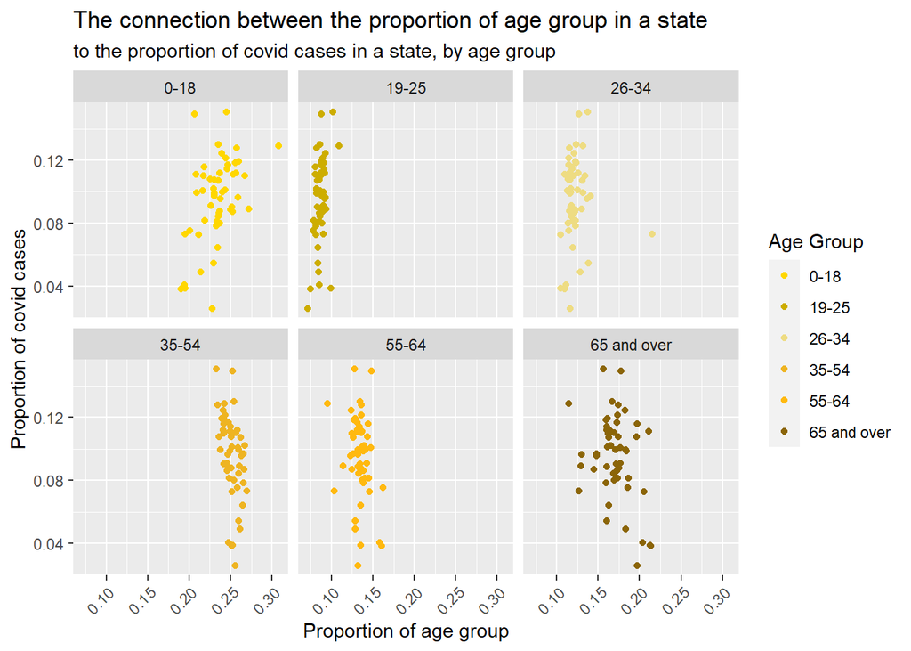

```r
ggplot(data = All_dates, aes(x = Percentage, y = total_cases, color = as.factor(age_group))) +
  geom_point(stat="identity")+
  theme(axis.text.x = element_text(angle = 45,hjust=1)) +
  facet_wrap(~age_group)+
  scale_color_manual(values=c("gold", "gold3", "lightgoldenrod2", "goldenrod2", "darkgoldenrod1", "darkgoldenrod4"))+
  labs(title = "The connection between the proportion of age group in a state ", subtitle = "to the proportion of covid cases in a state, by age group", x= "Proportion of age group", y = "Proportion of covid cases", color = "Age Group")
```

Let’s see what are the outliers in the facets:

```r
outliers <- All_dates %>%
  select(State, total_cases)%>%
  distinct()%>%
  arrange(desc(total_cases))
head(outliers, 2)
```

```
## # A tibble: 2 x 2
##   State total_cases
##   <chr>       <dbl>
## 1 ND          0.151
## 2 RI          0.149
```

We can see that North Dakota and Rhode Island are the states with the highest proportion of covid cases throughout the pandemic period.

```r
tail(outliers, 1)
```

```
## # A tibble: 1 x 2
##   State total_cases
##   <chr>       <dbl>
## 1 HI         0.0258
```

We can see that Hawaii is the state with the lowest proportion of covid cases throughout the pandemic period.

There is no a clear connection, let’s see if there is a connection to the death cases:

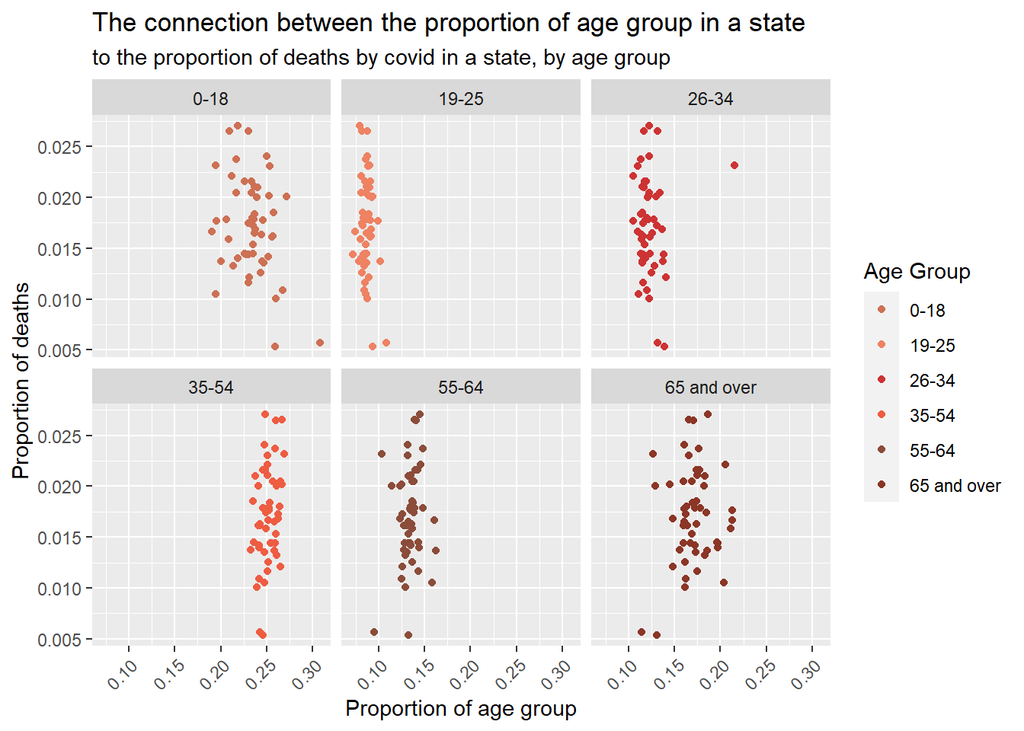

```r
ggplot(data = All_dates, aes(x = Percentage, y = total_deaths, color = as.factor(age_group))) +
  geom_point(stat="identity")+
  theme(axis.text.x = element_text(angle = 45,hjust=1)) +
  scale_color_manual(values=c("salmon3", "salmon2", "brown3", "tomato2", "salmon4", "tomato4"))+
  facet_wrap(~age_group)+
   labs(title = "The connection between the proportion of age group in a state ", subtitle = "to the proportion of deaths by covid in a state, by age group", x= "Proportion of age group", y = "Proportion of deaths", color = "Age Group")
```

Let’s see what are the outliers in the facets:

```r
outliers <- All_dates %>%
  select(State, total_deaths)%>%
  distinct()%>%
  arrange(desc(total_deaths))
tail(outliers, 2)
```

```
## # A tibble: 2 x 2
##   State total_deaths
##   <chr>        <dbl>
## 1 UT         0.00567
## 2 AK         0.00536
```

We can see that Alaska and Utah are the states with the lowest proportion of covid deaths throughout the pandemic period.

We can NOT see a clear connection between the amount of different age groups from the population in a state to the level of COVID cases/deaths. The reason is probably that with the time, we learned that COVID is attacking everyone, without connection to the age.

Maybe at the beginning of the pandemic there were more elders that was infected/died, and towards the end, the elders were much more careful and a balance was created.

So let’s check if at the beginning of the pandemic, there was a connection between the proportion of the age group in a state to the proportion of cases/deaths.

#### The connection between the proportion of specific age group, to the amount of covid cases/deaths at the beginning of the pandemic

```r
# Filter the "Covid_cases" to the first 3 months of COVID
Sum_cases_dead <- Covid_cases%>%
  filter(Date <= as.Date('2020-04-30'))%>%
  group_by(State, Region)%>%
  summarise(total_deaths = sum(Daily_new_death), total_cases = sum(Daily_new_cases),.groups="drop")

Beginning <- prepare(Sum_cases_dead)
```

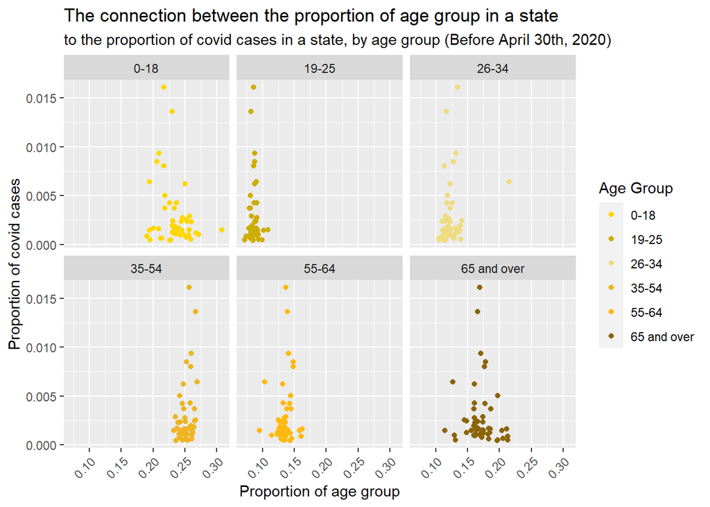

```r
# Plot
ggplot(data = Beginning, aes(x = Percentage, y = total_cases, color = as.factor(age_group))) +
  geom_point(stat="identity")+
  theme(axis.text.x = element_text(angle = 45,hjust=1)) +
  facet_wrap(~age_group)+
  scale_color_manual(values=c("gold", "gold3", "lightgoldenrod2", "goldenrod2", "darkgoldenrod1", "darkgoldenrod4"))+
   labs(title = "The connection between the proportion of age group in a state ", subtitle = "to the proportion of covid cases in a state, by age group (Before April 30th, 2020)", x= "Proportion of age group", y = "Proportion of covid cases", color = "Age Group")
```

Let’s see what are the outliers in the facets:

```r
outliers <- Beginning %>%
  select(State, total_cases)%>%
  distinct()%>%
  arrange(desc(total_cases))
head(outliers, 2)
```

```
## # A tibble: 2 x 2
##   State total_cases
##   <chr>       <dbl>
## 1 NY         0.0161
## 2 NJ         0.0136
```

We can see that New York and New Jersey are the states with the highest proportion of covid cases at the beginning of the pandemic period.

There is no clear connection, let’s see if there is a connection to the death cases:

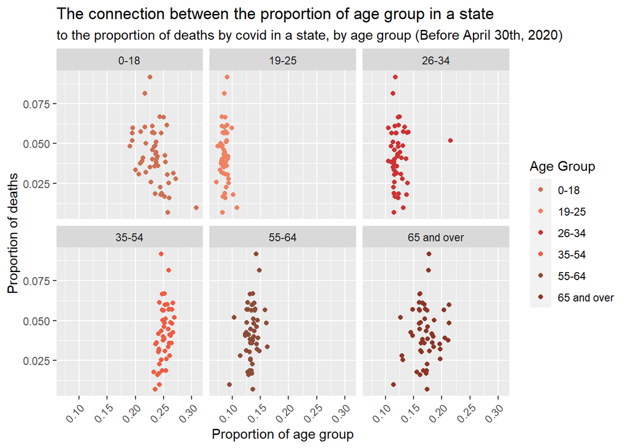

```r
# plot
ggplot(data = Beginning, aes(x = Percentage, y = total_deaths, color = as.factor(age_group))) +
  geom_point(stat="identity")+
  theme(axis.text.x = element_text(angle = 45,hjust=1)) +
    scale_color_manual(values=c("salmon3", "salmon2", "brown3", "tomato2", "salmon4", "tomato4"))+
  facet_wrap(~age_group)+
   labs(title = "The connection between the proportion of age group in a state ", subtitle = "to the proportion of deaths by covid in a state, by age group (Before April 30th, 2020) ", x= "Proportion of age group", y = "Proportion of deaths", color = "Age Group")
```

Let’s see what are the outliers in the facets:

```r
outliers <- Beginning %>%
  select(State, total_deaths)%>%
  distinct()%>%
  arrange(desc(total_deaths))
head(outliers, 2)
```

```
## # A tibble: 2 x 2
##   State total_deaths
##   <chr>        <dbl>
## 1 MI          0.0916
## 2 CT          0.0815
```

We can see that Michigan and Connecticut are the states with the highest proportion of covid deaths at the beginning of the pandemic period.

```r
tail(outliers, 1)
```

```
## # A tibble: 1 x 2
##   State total_deaths
##   <chr>        <dbl>
## 1 SD         0.00694
```

We can see that South Dakota is the state with the lowest proportion of covid deaths at the beginning of the pandemic period.

We can see slight connection at the groups of `0-18` and `65 and over`. Let’s see if there is an **incline** in the average amount of deaths in countries that has less than 15% of elders, to countries that has more than 15% of elders:

```r
# Maximum proportion of dead
Max_death <- (Beginning%>%
  filter(total_deaths==max(total_deaths)))$total_deaths[1]

# Average of the deaths percentage (less than 15% elders)
Average_deaths_less <- Beginning %>%
  filter(Percentage<=0.15 & age_group=="65 and over") %>%
  summarise(Average_deaths = mean(total_deaths))
Percentage_less <- Average_deaths_less$Average_deaths/Max_death*100

# Average of the deaths percentage (more than 15% elders)
Average_deaths_more<- Beginning %>%
  filter(Percentage>=0.15 & age_group=="65 and over") %>%
  summarise(Average_deaths = mean(total_deaths))
Percentage_more <- Average_deaths_more$Average_deaths/Max_death*100

cat(paste0("The Percentage of deaths among states that there is less than 15% of elders in is: ",round(Percentage_less, 2),"%", "\n", "The Percentage of deaths among states that there is more than 15% of elders in is: ",round(Percentage_more, 2),"%", "\n", "There is an incline of ", round(Percentage_more-Percentage_less, 2),  "% in the amount of deaths in countries with more elders."))
```

```
## The Percentage of deaths among states that there is less than 15% of elders in is: 39.76%
## The Percentage of deaths among states that there is more than 15% of elders in is: 46.93%
## There is an incline of 7.16% in the amount of deaths in countries with more elders.
```

Let’s see if there is a **decline** in the average amount of deaths in countries that have less than 25% of children, to countries that have more than 25% of children:

```r
# Average of the deaths percentage (less than 25% children)
Average_deaths_less <- Beginning%>%
  filter(Percentage<=0.25 & age_group=="0-18")%>%
  summarise(Average_deaths = mean(total_deaths))
Percentage_less <- Average_deaths_less$Average_deaths/Max_death*100

# Average of the deaths percentage (more than 25% children)
Average_deaths_more<- Beginning%>%
  filter(Percentage>=0.25 & age_group=="0-18")%>%
  summarise(Average_deaths = mean(total_deaths))
Percentage_more <- Average_deaths_more$Average_deaths/Max_death*100

cat(paste0("The Percentage of deaths among states that there is less than 25% of children in is: ",round(Percentage_less, 2),"%", "\n", "The Percentage of deaths among states that there is more than 25% of children in is: ",round(Percentage_more, 2),"%", "\n", "There is a decline of ", round(Percentage_less-Percentage_more, 2),  "% in the amount of deaths in countries with more children"))
```

```
## The Percentage of deaths among states that there is less than 25% of children in is: 50.12%
## The Percentage of deaths among states that there is more than 25% of children in is: 30.44%
## There is a decline of 19.68% in the amount of deaths in countries with more children
```

Overall, we can see that there is a slight connection for two groups. At the `65 and over` age group, there are more deaths in the countries that has higher proportion of elders. In addition, we can see that for the group of `0-18`- children, there are less deaths at the countries that has higher proportion of children.

Let’s see if we can see reverse connection towards the end of the pandemic, as we expect more elders to be careful.

#### The connection between the proportion of specific age group, to the amount of covid cases/deaths at the end of the pandemic

```r
# Filter the "Covid_cases" to the last 3 months of COVID
Sum_cases_dead <- Covid_cases%>%
  filter(Date >= as.Date('2021-03-01'))%>%
  group_by(State, Region) %>%
  summarise(total_deaths = sum(Daily_new_death), total_cases = sum(Daily_new_cases),.groups="drop")
End<- prepare(Sum_cases_dead)
```

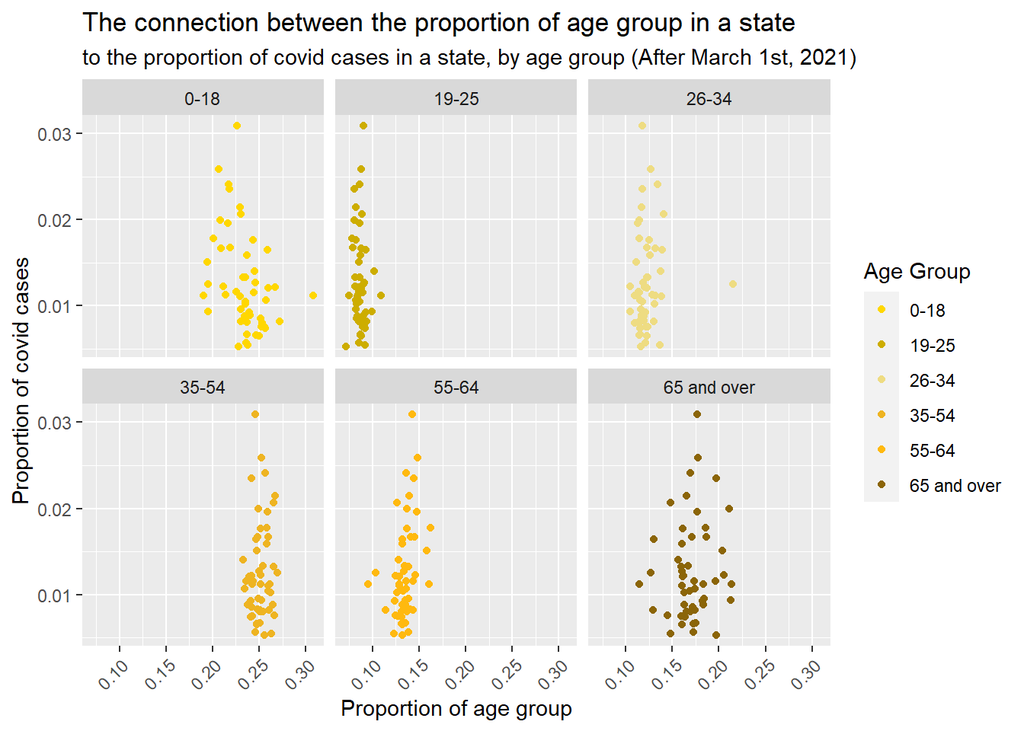

```r
# plot
ggplot(data = End, aes(x = Percentage, y = total_cases, color = as.factor(age_group))) +
  geom_point(stat="identity")+
  theme(axis.text.x = element_text(angle = 45,hjust=1)) +
  scale_color_manual(values=c("gold", "gold3", "lightgoldenrod2", "goldenrod2", "darkgoldenrod1", "darkgoldenrod4"))+
  facet_wrap(~age_group)+
   labs(title = "The connection between the proportion of age group in a state ", subtitle = "to the proportion of covid cases in a state, by age group (After March 1st, 2021)", x= "Proportion of age group", y = "Proportion of covid cases", color = "Age Group")
```

Let’s see what are the outliers in the facets:

```r
outliers <- End %>%
  select(State, total_cases)%>%
  distinct()%>%
  arrange(desc(total_cases))
head(outliers, 1)
```

```
## # A tibble: 1 x 2
##   State total_cases
##   <chr>       <dbl>
## 1 MI         0.0309
```

We can see that Michigan is the state with the highest proportion of covid cases at the end of the pandemic period.

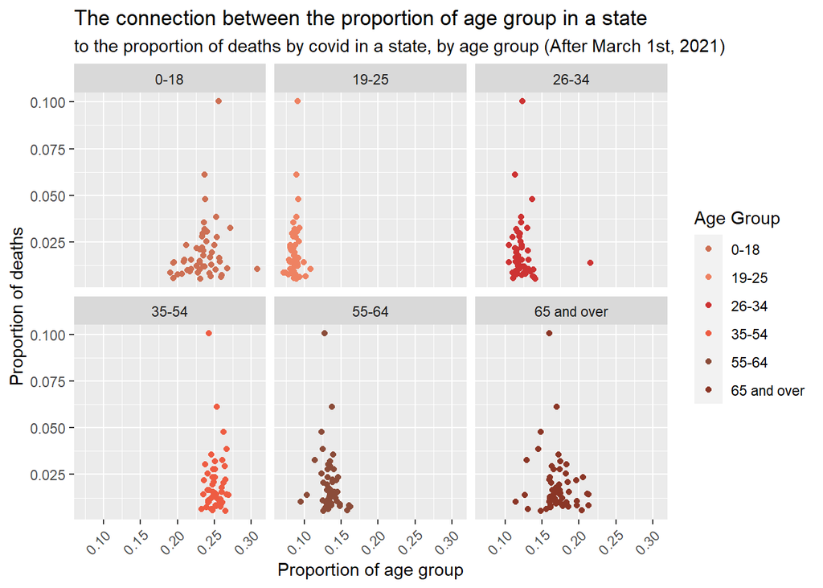

```r
# plot
ggplot(data = End, aes(x = Percentage, y = total_deaths, color = as.factor(age_group))) +
  geom_point(stat="identity")+
  theme(axis.text.x = element_text(angle = 45,hjust=1)) +
  scale_color_manual(values=c("salmon3", "salmon2", "brown3", "tomato2", "salmon4", "tomato4"))+
  facet_wrap(~age_group)+
   labs(title = "The connection between the proportion of age group in a state ", subtitle = "to the proportion of deaths by covid in a state, by age group (After March 1st, 2021) ", x= "Proportion of age group", y = "Proportion of deaths", color = "Age Group")
```

Let’s see what are the outliers in the facets:

```r
outliers <- End %>%
  select(State, total_deaths)%>%
  distinct()%>%
  arrange(desc(total_deaths))
head(outliers, 1)
```

```
## # A tibble: 1 x 2
##   State total_deaths
##   <chr>        <dbl>
## 1 OK           0.100
```

We can see that Oklahoma is the state with the highest proportion of covid deaths at the end of the pandemic period.

We didn’t find a connection in the last 3 months.

#### The connection between the proportion of specific age group, to the amount of covid cases/deaths at the peak of the pandemic

```r
# Filter the "Covid_cases" to January, 2021
Sum_cases_dead <- Covid_cases%>%
  filter(Date >= as.Date('2021-01-01'))%>%
  filter(Date <= as.Date('2021-02-01'))%>%
  group_by(State, Region) %>%
  summarise(total_deaths = sum(Daily_new_death), total_cases = sum(Daily_new_cases),.groups="drop")
Peak<- prepare(Sum_cases_dead)
```

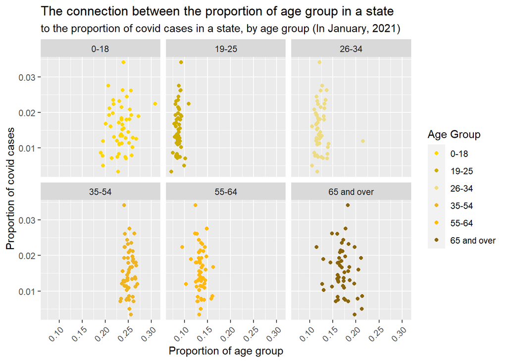

```r
# plot
ggplot(data = Peak, aes(x = Percentage, y = total_cases, color = as.factor(age_group))) +
  geom_point(stat="identity")+
  theme(axis.text.x = element_text(angle = 45,hjust=1)) +
  scale_color_manual(values=c("gold", "gold3", "lightgoldenrod2", "goldenrod2", "darkgoldenrod1", "darkgoldenrod4"))+
  facet_wrap(~age_group)+
   labs(title = "The connection between the proportion of age group in a state ", subtitle = "to the proportion of covid cases in a state, by age group (In January, 2021)", x= "Proportion of age group", y = "Proportion of covid cases", color = "Age Group")
```

Let’s see what are the outliers in the facets:

```r
outliers <- Peak %>%
  select(State, total_cases)%>%
  distinct()%>%
  arrange(desc(total_cases))
head(outliers, 1)
```

```
## # A tibble: 1 x 2
##   State total_cases
##   <chr>       <dbl>
## 1 AZ         0.0341
```

We can see that Arizona is the state with the highest proportion of covid cases at the peak of the pandemic period.

```r
tail(outliers, 2)
```

```
## # A tibble: 2 x 2
##   State total_cases
##   <chr>       <dbl>
## 1 PR        0.00499
## 2 HI        0.00338
```

We can see that Puerto Rico and Hawaii are the states with the lowest proportion of covid cases at the peak of the pandemic period.

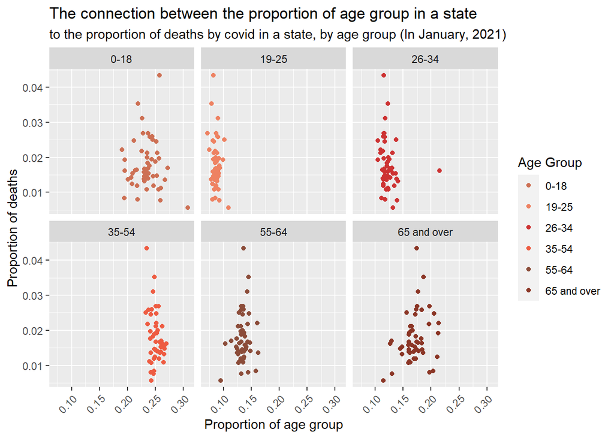

```r
# plot
ggplot(data = Peak, aes(x = Percentage, y = total_deaths, color = as.factor(age_group))) +
  geom_point(stat="identity")+
  theme(axis.text.x = element_text(angle = 45,hjust=1)) +
  scale_color_manual(values=c("salmon3", "salmon2", "brown3", "tomato2", "salmon4", "tomato4"))+
  facet_wrap(~age_group)+
   labs(title = "The connection between the proportion of age group in a state ", subtitle = "to the proportion of deaths by covid in a state, by age group (In January, 2021) ", x= "Proportion of age group", y = "Proportion of deaths", color = "Age Group")
```

Let’s see what are the outliers in the facets:

```r
outliers <- Peak %>%
  select(State, total_deaths)%>%
  distinct()%>%
  arrange(desc(total_deaths))
head(outliers, 3)
```

```
## # A tibble: 3 x 2
##   State total_deaths
##   <chr>        <dbl>
## 1 SD          0.0434
## 2 PA          0.0353
## 3 MI          0.0311
```

We can see that South Dakota, Pennsylvania and Michigan are the states with the highest proportion of covid deaths at the peak of the pandemic period.

We can see slight connection at the group of `65 and over`. Let’s see if there is an **incline** in the average amount of deaths in countries that has less than 15% of elders, to countries that has more than 15% of elders:

```r
# Maximum proportion of dead
Max_death <- (Peak%>%
  filter(total_deaths==max(total_deaths)))$total_deaths[1]

# Average of the deaths percentage (less than 15% elders)
Average_deaths_less <- Peak %>%
  filter(Percentage<=0.15 & age_group=="65 and over") %>%
  summarise(Average_deaths = mean(total_deaths))
Percentage_less <- Average_deaths_less$Average_deaths/Max_death*100

# Average of the deaths percentage (more than 15% elders)
Average_deaths_more<- Peak %>%
  filter(Percentage>=0.15 & age_group=="65 and over") %>%
  summarise(Average_deaths = mean(total_deaths))
Percentage_more <- Average_deaths_more$Average_deaths/Max_death*100

cat(paste0("The Percentage of deaths among states that there is less than 15% of elders in is: ",round(Percentage_less, 2),"%", "\n", "The Percentage of deaths among states that there is more than 15% of elders in is: ",round(Percentage_more, 2),"%", "\n", "There is an incline of ", round(Percentage_more-Percentage_less, 2),  "% in the amount of deaths in countries with more elders."))
```

```
## The Percentage of deaths among states that there is less than 15% of elders in is: 29.53%
## The Percentage of deaths among states that there is more than 15% of elders in is: 42.73%
## There is an incline of 13.2% in the amount of deaths in countries with more elders.
```

Overall, we can see that there is a connection for the group of `65 and over` age group, there are more deaths in the countries that has higher proportion of elders at the peak of the pandemic.

### For conclusion

We cannot say that the answer to our question is yes, but we did find that for certain periods of time - until April 30th, 2020, and in the peak of the pandemic, at January, 2021, the size of a certain age group - elders or children in a state, affect the number of people that died from Corona virus in that state.